# Modelaje Epidemiológico en `R`

## Ajustes de distribución mediante kernel

Como en general, para datos reales es extremadamente raro que sigan una distribución de las conocidas se utiliza una densidad `kernel` para ajustar los datos. Ésta es como un histograma *pero continuo*. Existen distintos métodos, en general Epanechnikov es una buena idea

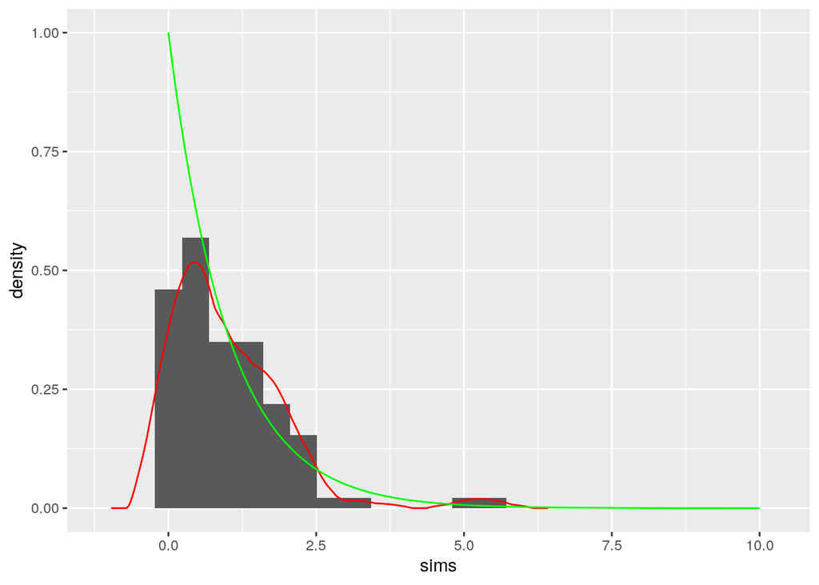

```r
nsims        <- 100
x            <- seq(0,10, length.out = 1000)
mis.sims     <- data.frame(sims = rexp(nsims))
mi.kernel    <- density(mis.sims$sims, kernel = "epanechnikov", n = 1000)
datos.kernel <- data.frame(x = mi.kernel$x, y = mi.kernel$y)
verdadero    <- data.frame(x = x, y = dexp(x))


#Graficamos
ggplot(datos.kernel) +
  geom_histogram(aes(x = sims, y = ..density..), data = mis.sims, bins = 25) +
  geom_line(aes(x = x, y = y), color = "red") +
  geom_line(aes(x = x, y = y), color = "green", data = verdadero)
```

Observa que el `kernel` se parece más y más a la distribución verdadera conforme aumentamos el tamaño:

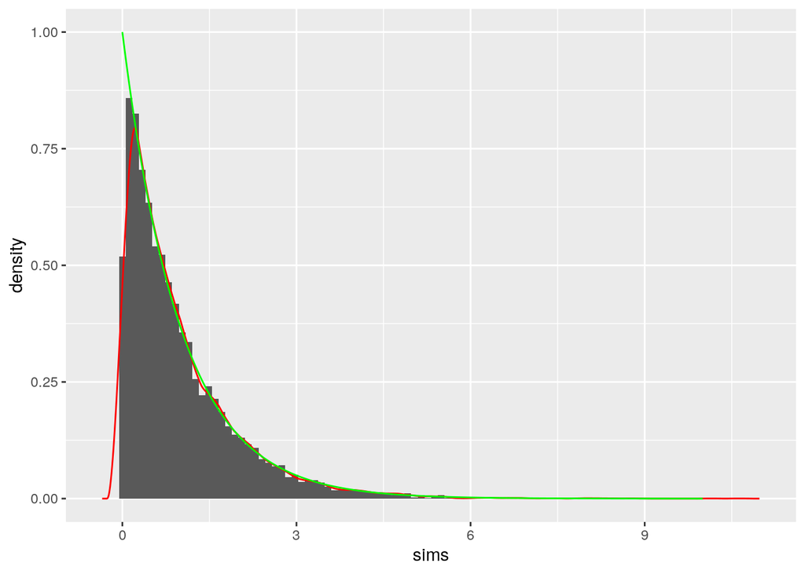

```r
nsims        <- 10000
mis.sims     <- data.frame(sims = rexp(nsims))
mi.kernel    <- density(mis.sims$sims, kernel = "epanechnikov", n = 1000)
datos.kernel <- data.frame(x = mi.kernel$x, y = mi.kernel$y)
verdadero    <- data.frame(x = x, y = dexp(x))


#Graficamos
ggplot(datos.kernel) +
  geom_histogram(aes(x = sims, y = ..density..),
                 data = mis.sims, bins = 100) +
  geom_line(aes(x = x, y = y), color = "red") +
  geom_line(aes(x = x, y = y), color = "green", data = verdadero)
```

Las densidades `kernel` son unos de los objetos de la estadística no paramétrica. Ésta consiste en eliminar algunas de las hipótesis (por ejemplo, dejar de agregar la hipótesis pesadísima de que los datos siguen una distribución normal) y dejarse llevar por los datos prácticamente sin ninguna hipótesis de por medio. Volveremos a las densidades más adelante.

# Regresión lineal

## Idea: Regresión lineal de una variable contra otra

La idea de una regresión lineal simple entre dos variables es ajustar una línea recta que explique cómo se relacionan dos datos (llamémosle `x` y `y`) Recuerda que la ecuación de una recta es:
$$y = \underbrace{m}_{\text{Pendiente}} \cdot x + \overbrace{b}^{\text{Ordenada}}$$

Mucha gente habla de variables dependientes e independientes. Son términos anticuados que ya no se usan en estadística porque en realidad ambas son dependientes de sí.

La pendiente determina la inclinación de la recta:

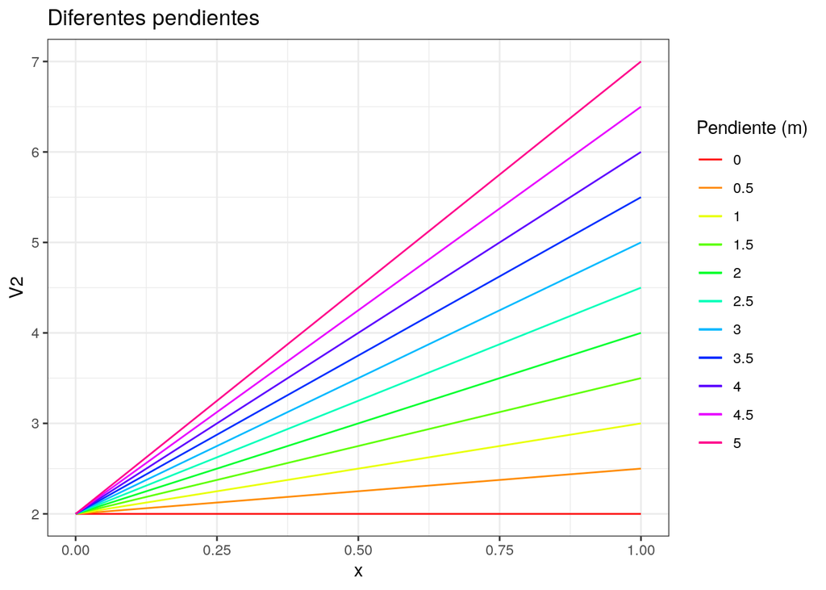

```r
linea_pendiente <- function(m){
  x <- seq(0, 1, length.out = 100)
  y <- m*x + 2
  return(y)
}

#Creamos varias líneas
x      <- seq(0, 1, length.out = 100)
lineas <- sapply(seq(0, 5, by = 0.5), linea_pendiente)
lineas <- cbind(x, lineas)

#Lines
ggplot(as.data.frame(lineas)) +
  geom_line(aes(x = x, y = V2, color = "0")) +
  geom_line(aes(x = x, y = V3, color = "0.5")) +
  geom_line(aes(x = x, y = V4, color = "1")) +
  geom_line(aes(x = x, y = V5, color = "1.5")) +
  geom_line(aes(x = x, y = V6, color = "2")) +
  geom_line(aes(x = x, y = V7, color = "2.5")) +
  geom_line(aes(x = x, y = V8, color = "3")) +
  geom_line(aes(x = x, y = V9, color = "3.5")) +
  geom_line(aes(x = x, y = V10, color = "4")) +
  geom_line(aes(x = x, y = V11, color = "4.5")) +
  geom_line(aes(x = x, y = V12, color = "5")) +
  scale_color_manual("Pendiente (m)", values = rainbow(11)) +
  theme_bw() +
  ggtitle("Diferentes pendientes")
```

Mientras que la ordenada determina por dónde toca el eje de las ordenadas ($y$):

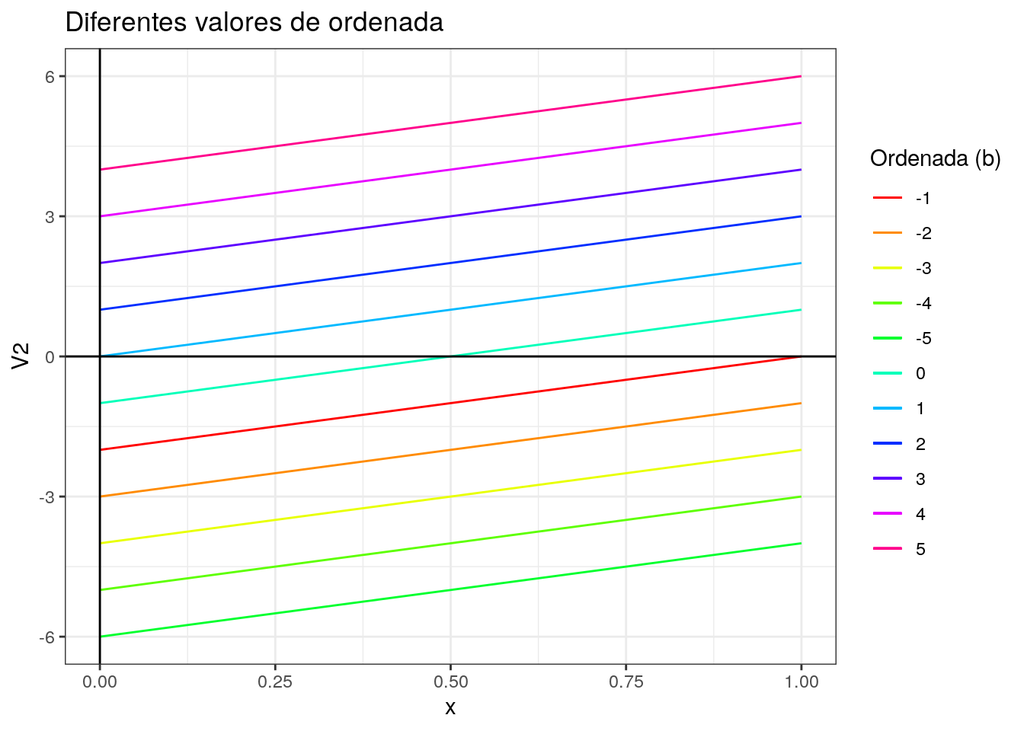

```r
linea_ordenada <- function(b){
  x <- seq(-1, 1, length.out = 100)
  y <- x + b
  return(y)
}

#Creamos varias líneas
x      <- seq(0, 1, length.out = 100)
lineas <- sapply(seq(-5, 5, by = 1), linea_ordenada)
lineas <- cbind(x, lineas)

#Lines
ggplot(as.data.frame(lineas)) +
  geom_line(aes(x = x, y = V2, color = "-5")) +
  geom_line(aes(x = x, y = V3, color = "-4")) +
  geom_line(aes(x = x, y = V4, color = "-3")) +
  geom_line(aes(x = x, y = V5, color = "-2")) +
  geom_line(aes(x = x, y = V6, color = "-1")) +
  geom_line(aes(x = x, y = V7, color = "0")) +
  geom_line(aes(x = x, y = V8, color = "1")) +
  geom_line(aes(x = x, y = V9, color = "2")) +
  geom_line(aes(x = x, y = V10, color = "3")) +
  geom_line(aes(x = x, y = V11, color = "4")) +
  geom_line(aes(x = x, y = V12, color = "5")) +
  scale_color_manual("Ordenada (b)", values = rainbow(11)) +
  theme_bw() +
  geom_vline(aes(xintercept = 0)) +
  geom_hline(aes(yintercept = 0)) +
  ggtitle("Diferentes valores de ordenada")
```

En una regresión lineal simple el problema consiste en determinar la línea que mejor explique la variable a predecir `y` en función de mis observaciones `x`. Para ello, vamos a jugar con una base completamente inventada antes de analizar datos reales.

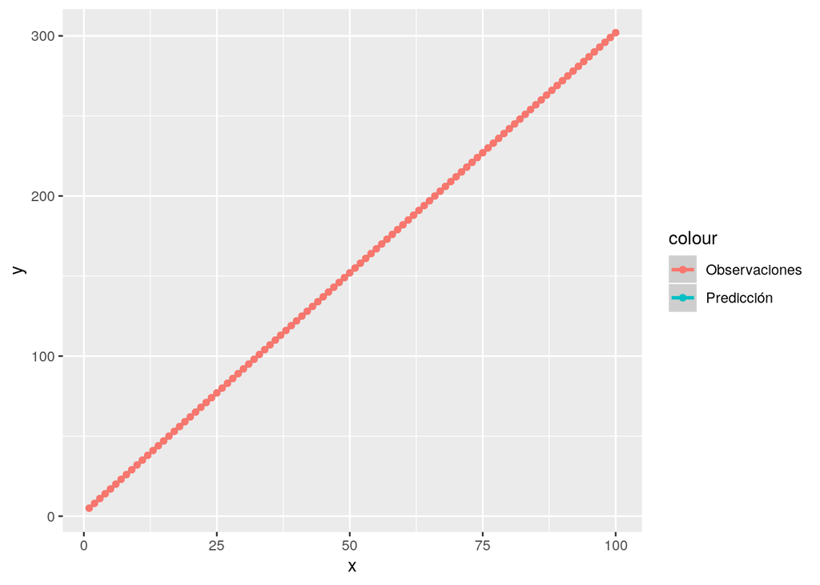

```r
#Genero una línea recta
base1 <- data.frame(x = 1:100, y = 3*(1:100) + 2)

ggplot(base1, aes(x = x, y = y)) +
  geom_smooth(aes(x = x, y = y, color = "Predicción"), method = "lm") +
  geom_point(aes(x = x, y = y, color = "Observaciones"))
```

Éste es un modelo perfecto de regresión lineal. Veamos los resultados del modelo (sin graficar) de `R`:

```r
#Correr la regresión aparentemente no hace nada
modelo1 <- lm(y ~ x, data = base1)
summary(modelo1)
```

```
##
## Call:
## lm(formula = y ~ x, data = base1)
##
## Residuals:
##        Min         1Q     Median         3Q        Max
## -1.970e-13 -5.301e-15 -6.710e-16  2.534e-15  1.859e-13
##
## Coefficients:
##              Estimate Std. Error   t value Pr(>|t|)
## (Intercept) 2.000e+00  5.745e-15 3.482e+14   <2e-16 ***
## x           3.000e+00  9.876e-17 3.038e+16   <2e-16 ***
## ---
## Signif. codes:  0 '***' 0.001 '**' 0.01 '*' 0.05 '.' 0.1 ' ' 1
##
## Residual standard error: 2.851e-14 on 98 degrees of freedom
## Multiple R-squared:      1,  Adjusted R-squared:      1
## F-statistic: 9.228e+32 on 1 and 98 DF,  p-value: < 2.2e-16
```

Podemos además ver gráficas de diagnostico para cada uno de los resultados:

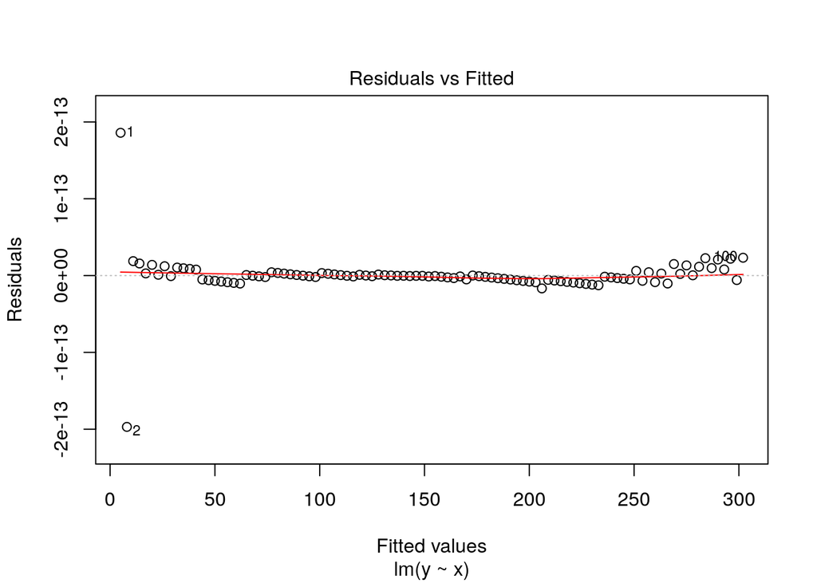

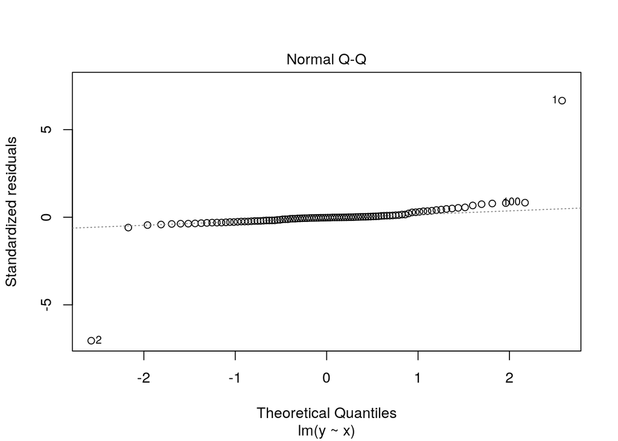

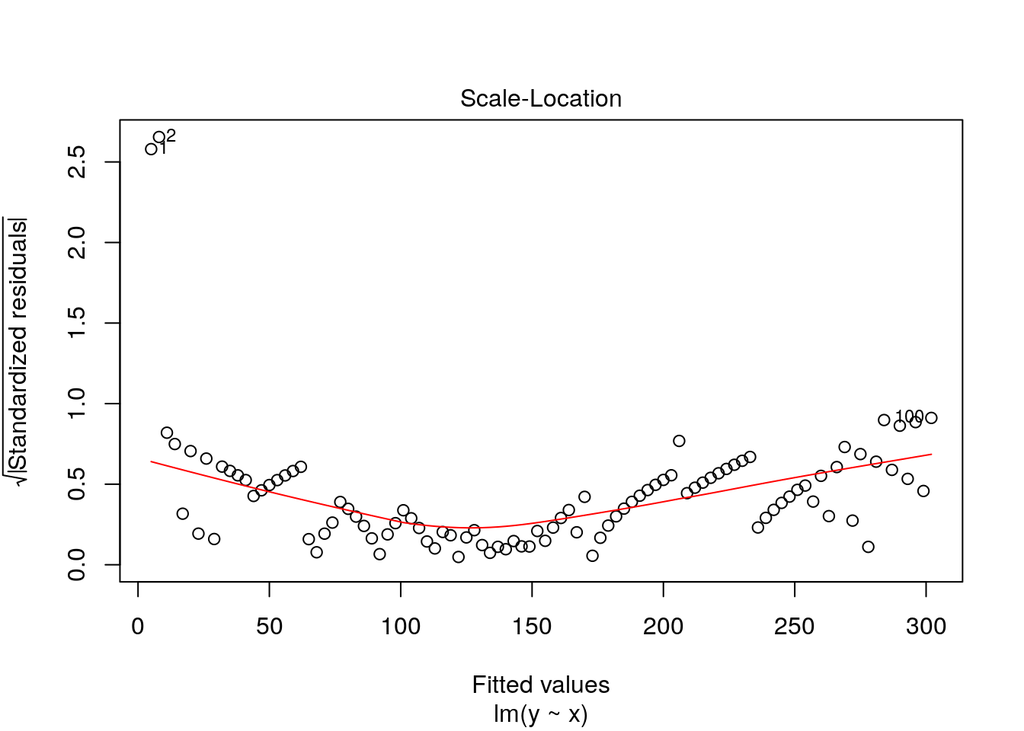

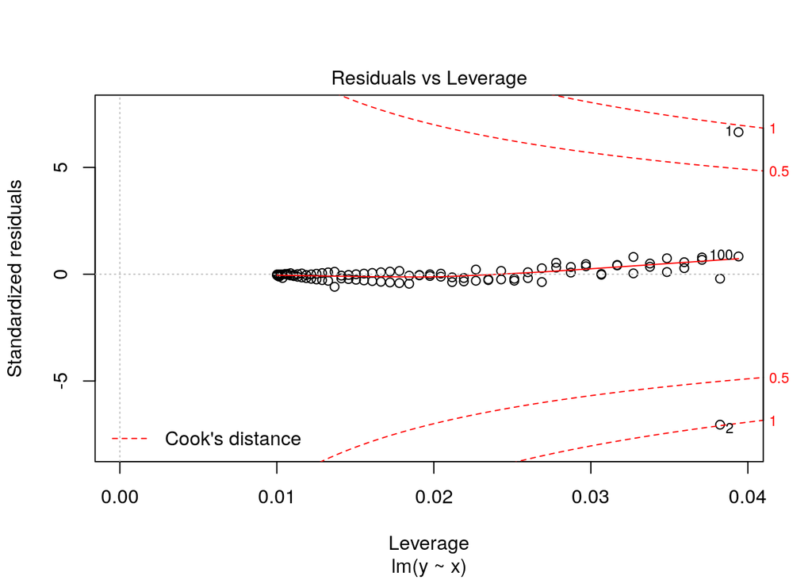

```r
plot(modelo1)
```

En este caso que el modelo es perfecto: parecidas a estas debe ser un buen modelo. Veamos cómo cambia la regresión si cambiamos uno de los puntos y agregamos un outlier:

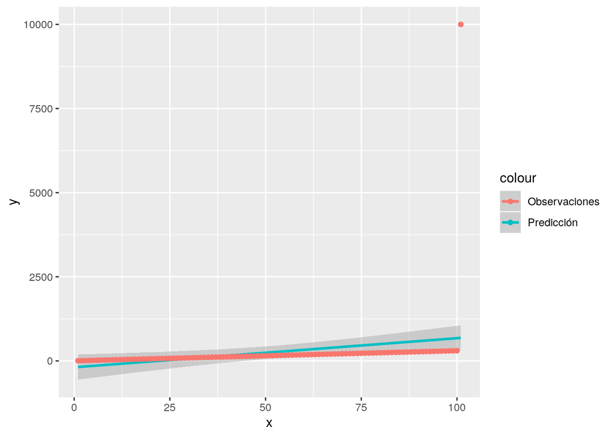

```r
library("tidyverse")
base2 <- base1 %>% bind_rows(c(x = 101, y = 10000))

ggplot(base2, aes(x = x, y = y)) +
  geom_smooth(aes(x = x, y = y, color = "Predicción"), method = "lm") +
  geom_point(aes(x = x, y = y, color = "Observaciones"))
```

¡Un solo *outlier* nos cambió toda la línea! Veamos si cambia algo en el `summary`:

```r
#Correr la regresión aparentemente no hace nada
modelo2 <- lm(y ~ x, data = base2)
summary(modelo2)
```

```
##
## Call:
## lm(formula = y ~ x, data = base2)
##
## Residuals:
##    Min     1Q Median     3Q    Max
## -372.7 -231.5  -90.3   50.8 9316.7
##
## Coefficients:
##             Estimate Std. Error t value Pr(>|t|)
## (Intercept) -189.980    191.509  -0.992  0.32361
## x              8.646      3.260   2.652  0.00931 **
## ---
## Signif. codes:  0 '***' 0.001 '**' 0.01 '*' 0.05 '.' 0.1 ' ' 1
##
## Residual standard error: 955.2 on 99 degrees of freedom
## Multiple R-squared:  0.06634,    Adjusted R-squared:  0.05691
## F-statistic: 7.035 on 1 and 99 DF,  p-value: 0.009312
```

Nota que `R` ya no está seguro del intercepto: incrementamos el error horriblemente y la $R^2$ (ahora volvemos a ella) disminuyó a casi nada. Finalmente, estudiemos esto en las gráficas de diagnostico:

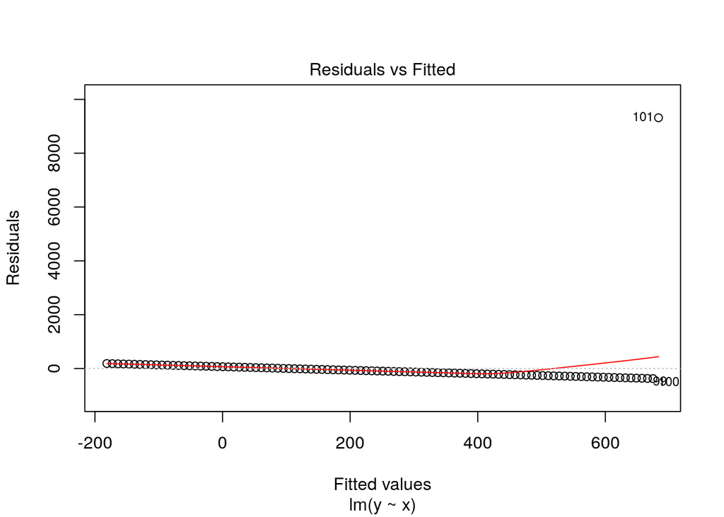

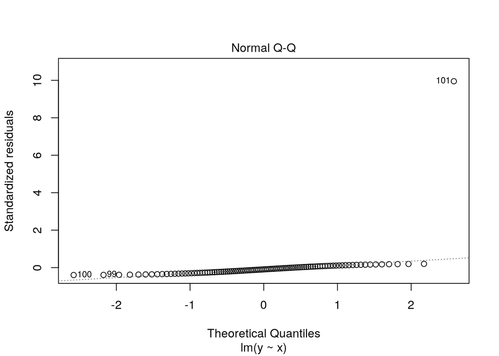

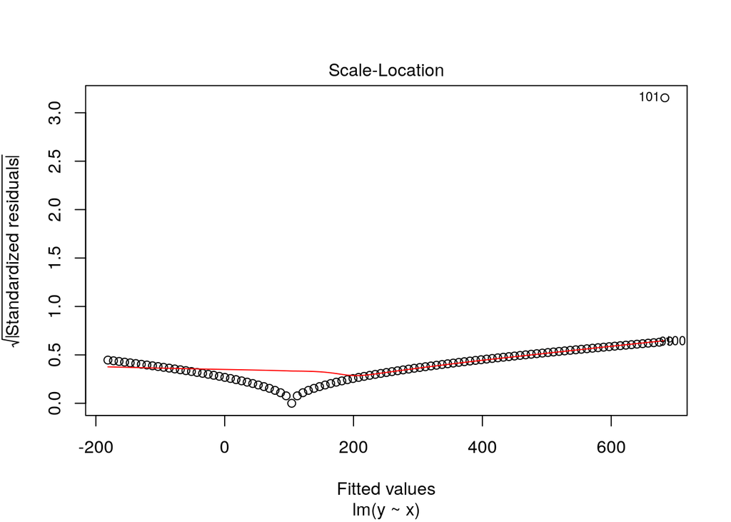

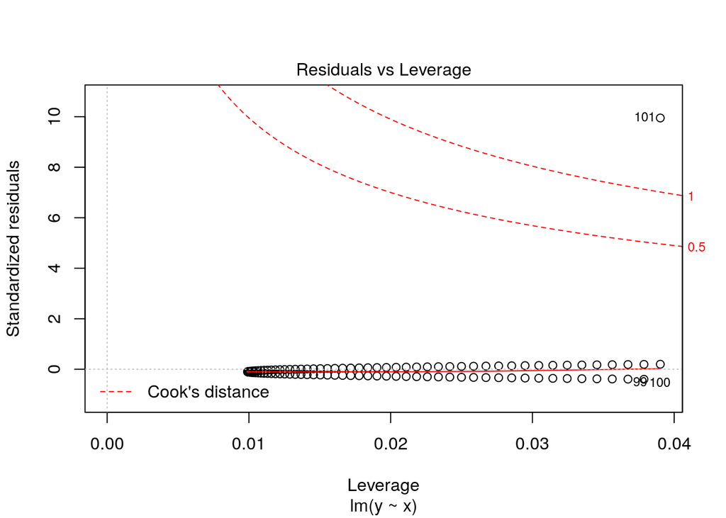

```r
plot(modelo2)
```

Observa que los residuales contra ajustados se desvía al final lo que nos dice que no es buen ajuste para los últimos. El `qqplot` muestra que el ajuste es bueno para las variables de en medio pero no los extremos; finalmente, el apalancamiento nos muestra que la observación `101` está apalancando mucho: ¡es un outlier!